# DATA 622: Homework 2

Andrew Bowen

2024-03-25

## Decision Trees

[This article covers decision trees](https://decizone.com/blog/the-good-the-bad-the-ugly-of-using-decision-trees), as well as the advantages and disadvantages of using them. In this analysis, I train two decision trees on a [kaggle dataset](https://www.kaggle.com/datasets/dtrade84/nfl-elo-ratings) containing the ELO ratings of NFL teams prior to their games. This information is leveraged to train models to predict the winner of a particular game (either the *Home* or *Away* team). In addition, I train a random forest classifier on a subset of features (simialr to one of the decision trees) to predict the same outcomes.

While decision trees can be simple, yet effective, they do have some drawbacks. The primary drawback is the tendency of decision trees to overfit to their training data. This comes from the tendency of decision trees to grow the number of leaf nodes with the number of features (This was discussed int he article under the *Complexity* disadvantage). This results in a tree that can predict training values well, because it grows to the shape of the trainig data, but not more generally. Trees that undergo this sort of training will not always generalize well, and pruning decision trees can be a worthwhiel endeavor. *Data Science for Business (Provost & Fawcett* is a good resource that discusses handling decision trees in a business modeling context well.

## Data Analys

**For this assignment, our classification task will be to try to predict whether the home team or away team will win a given NFL game, based on the respective ELO ratings prior to the game, along with other features included in the Kaggle dataset.**

We’ll be using the NFL ELO rating dataset we used in homework 1. [This dataset](https://www.kaggle.com/datasets/dtrade84/nfl-elo-ratings) comes from Kaggle, and contains the [ELO ratings](https://en.wikipedia.org/wiki/Elo_rating_system) of NFL teams both before and after their matchups, as well as the points scored by each team in the game. More information on the FiveThirtyEight method which calculates these ELO ratings can be [found here](https://fivethirtyeight.com/methodology/how-our-nfl-predictions-work/).

```r
elo <- read_csv("data/nfl_elo.csv")

# Some basic handling of team renames, as well as a boolean winner column
elo <- elo %>%
  mutate(team1 = ifelse(team1=="WSH", "WAS", team1),
         team2 = ifelse(team2=="WSH", "WAS", team2),
         winner = ifelse(score1 > score2, "Home", "Away"))

elo$winner <- as.factor(elo$winner)
```

## Exploratory Data Analysis

First, let’s take a quick look at the distribution of pre-game ELO ratings of each team (home & away):

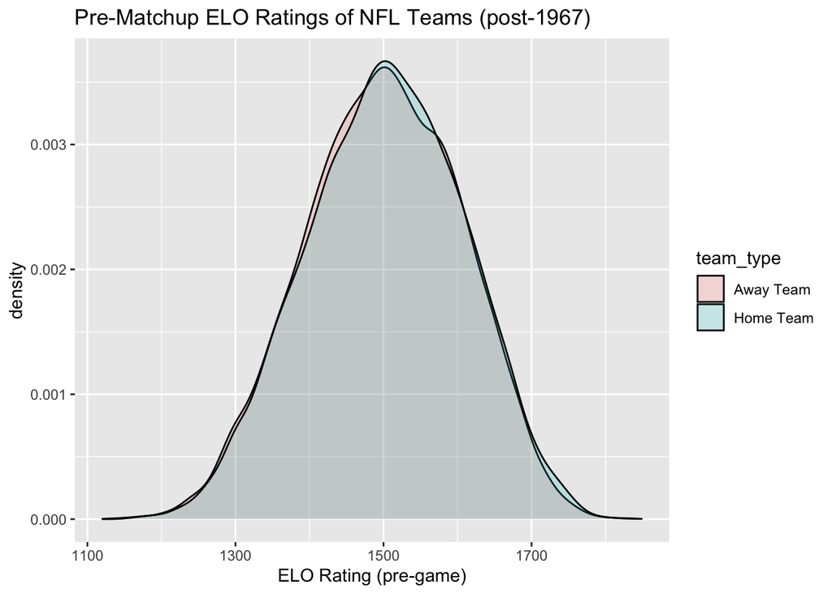

```r
prelo1 <- elo %>%
  rename(elo = elo1_pre, team=team1) %>%
  select(c("team", "elo")) %>%
  mutate(team_type = "Home Team")
prelo2 <- elo %>%
  rename(elo = elo2_pre, team=team2) %>%
  select(c("team", "elo")) %>%
  mutate(team_type = "Away Team")
prelo <- rbind(prelo1, prelo2)

# Plot pre-game ELO ratings for home and away teams
ggplot(prelo, aes(elo, fill = team_type)) +
  geom_density(alpha = 0.2) +
  labs(x="ELO Rating (pre-game)", title="Pre-Matchup ELO Ratings of NFL Teams (post-1967)")
```

Both our distributions of pre-game ELO ratings for home and away teams look relatively normally distributed. This is helpful to know before we go into modeling, as some modeling algorithms expect normally distributed (and sometimes scaled & centered) data.

Let’s also take a look at the pair plot of our joint distribuions between our features and output variable (`winner`)

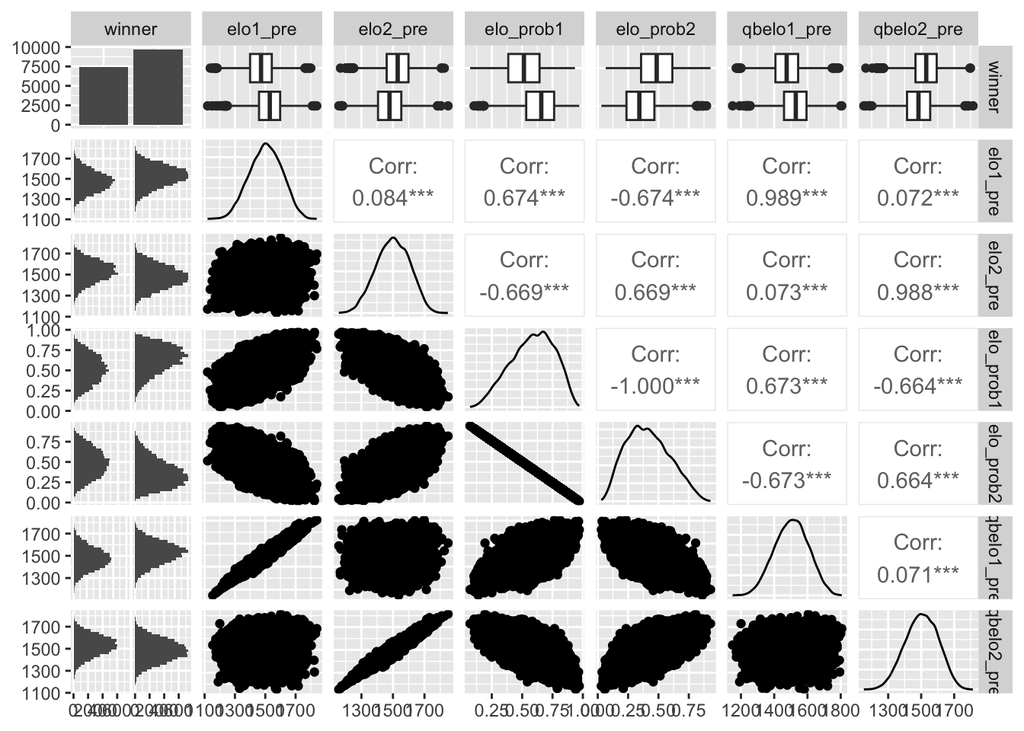

```r
elo %>% select(winner, elo1_pre, elo2_pre, elo_prob1, elo_prob2, qbelo1_pre, qbelo2_pre) %>%
  ggpairs()
```

We’ll also want to check for any collinearity between our feature variables, as well as with our output. This will help to protect us against redundancy of input features into our model, as well as helping to make sure our predictors explain the highest amount of variance in the response possible.

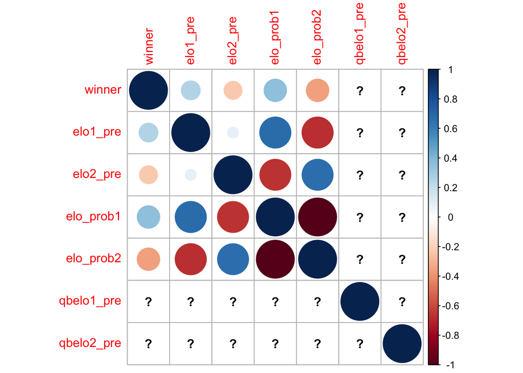

```r
elo %>% mutate(winner=ifelse(winner== "Home", 1, 0)) %>% select(winner, elo1_pre, elo2_pre, elo_prob1, elo_prob2, qbelo1_pre, qbelo2_pre) %>% cor() %>% corrplot()
```

```r
freq.na(elo)
```

```
##                missing  %
## importance       16810 98
## total_rating     16810 98
## playoff          16492 96
## qbelo1_pre        2162 13
## qbelo2_pre        2162 13
## qb1               2162 13
## qb2               2162 13
## qb1_value_pre     2162 13
## qb2_value_pre     2162 13
## qb1_adj           2162 13
## qb2_adj           2162 13
## qbelo_prob1       2162 13
## qbelo_prob2       2162 13
## qb1_game_value    2162 13
## qb2_game_value    2162 13
## qb1_value_post    2162 13
## qb2_value_post    2162 13
## qbelo1_post       2162 13
## qbelo2_post       2162 13
## quality           2162 13
## date                 0  0
## season               0  0
## neutral              0  0
## team1                0  0
## team2                0  0
## elo1_pre             0  0
## elo2_pre             0  0
## elo_prob1            0  0
## elo_prob2            0  0
## elo1_post            0  0
## elo2_post            0  0
## score1               0  0
## score2               0  0
## winner               0  0
```

We see from our NA frequency table that we have some fields of interest for which we’ll want to impute missing values. We can fill in these missing values via the R `mice` package

```r
# Impute all values in our training data
input_cols <- c("elo1_pre", "elo2_pre",
                "elo_prob1", "elo_prob2",
                "qbelo1_pre", "qbelo2_pre",
                "qb1_value_pre", "qb2_value_pre",
                "qb1_adj", "qb2_adj")
naive_inputs <- elo[, input_cols ]
imputed_qb_ratings <- mice(naive_inputs, meth='pmm')
imputedData <- complete(imputed_qb_ratings, 1)

imputedData$winner <- elo$winner
```